# Series de tiempo en R

Martín Paladino[^1]

8 de marzo de 2017

# Introducción. El objeto de este documento.

Las series de tiempo son series de datos –en sentido estadístico: variables– ordenadas por orden temporal y con algún tipo de índice que indica el tiempo al que corresponde esa observación. La secuencia comúnmente se organiza en puntos de tiempo con una separación igual, en ese caso son series tiempo con intervalos iguales. iguales. Las series de tiempo también tienen puede tener intervalos desiguales, cuando el evento que se registra no ocurre con una periodicidad establecida. Valgan como ejemplo un registro de exportaciones trimestrales –con un dato por cada trimestre, así sea 0– y las exportaciones registradas en año, mes, día, hora, segundo, registradas idealmente cada vez que se realiza una venta a un agente económico extranjero.[^2]

```r
#Librerías básicas.

library(tidyverse)
```

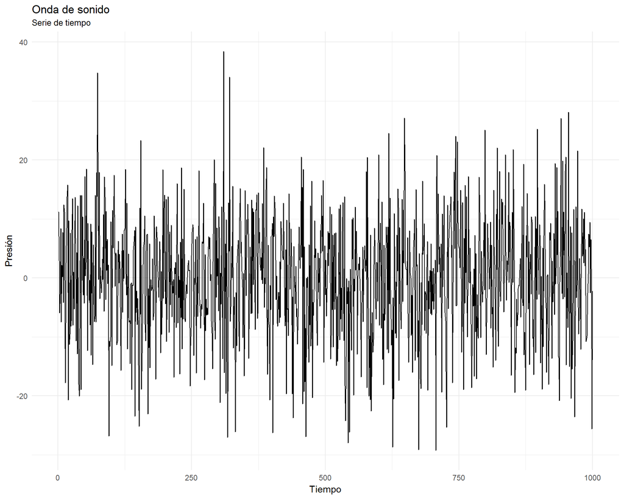

```r
library(inegiR)       #Requiere token de INEGI

#Onda sonora.

qplot(1:1000,rnorm(1000, 0, 10), geom="line") +
  labs(x="Tiempo",
  y="Presión",
  title="Onda de sonido",
  subtitle="Serie de tiempo") +
  theme_minimal()
```

# Series de tiempo con datos económicos.

## Agregar series de tiempo en años, semestres, trimestres.

En R expresamos una serie de tiempo con dos o más vectores, uno con el punto de tiempo y otro con el valor correspondiente. Es conveniente organizar estos vectores en una estructura data.frame, para asegurarnos que se mantengan alienados. Idealmente el vector índice de tiempo debe tener una fecha -y hora, minutos, segundos si aplica- completa: año, mes, día con separadores claros, respetando el mismo formato a lo largo de toda la serie. Si la marca de tiempo tiene el formato correcto es posible hacer agregar datos con facilidad.  
La librería `lubridate::`, de Hadley Wickham, tiene funciones para el manejo de fechas. Como es de esperar funciona muy bien con `dplyr::` y nos permite pasar los argumentos `year()`, `month()`, `semester()`, `quarter()`, `week()`, etc. a `group_by()`. La mayor dificultad es asegurarnos que el índice temporal es un objeto de la clase fecha (Date en R). Más adelante veremos formas de pasar un objeto a la clase Date. Por ahora usaremos series que descargadas con la librería `inegiR::`, que regresan un data.frame con la columna `Fechas` perfectamente formateada como fecha y con el atributo de clase correcto: `Date`.

```r
exportaciones <-
  series_exportaciones_pais(token) #Descargo la serie de exportaciones de México y la asingo a exportaciones
head(exportaciones, 15)            #¿Qué hay?
```

```
##        Fechas Estados Unidos Canada China Centro America America del Sur
## 1  1993-01-01        2754262  91693   165          45952          204647
## 2  1993-02-01        3180064  94520    88          40857           98361
## 3  1993-03-01        3639819 115056  6097          57980          150028
## 4  1993-04-01        3450809 107534 12050          58789          108196
## 5  1993-05-01        3420962 111286 12056          52206          111118
## 6  1993-06-01        3962358 173391  2767          69942          152520
## 7  1993-07-01        3358342 145135   713          76656          128003
## 8  1993-08-01        3447055 116799   781          59703          112691
## 9  1993-09-01        3683573 171965   817          46547          129580
## 10 1993-10-01        4118975 172855  6131          49942          123713
## 11 1993-11-01        3942707 156906  1240          47476          124825
## 12 1993-12-01        3952624 105721  1876          54914          160395
## 13 1994-01-01        3415987 149989  2096          46098          113751
## 14 1994-02-01        3895192 132880  2263          47242          103965
## 15 1994-03-01        4373030 172664 10057          55777          128613
```

```r
library(lubridate)                 #Se carga también con library(tidyverse).
class(exportaciones$Fechas)        #Clase de la columna Fechas. Es Date, no tendremos problemas.
```

```
## [1] "Date"
```

```r
is.Date(exportaciones$Fechas)      #Otra forma de verificar que una columna de fechas esté en formato de fecha. Debe regresar TRUE
```

```
## [1] TRUE
```

```r
          #================================#
          #Agregados de series temporales. #
          #================================#


#Serie anualizada. year()
#========================
exportaciones %>%
  group_by(year(Fechas)) %>%                      #Acá va la magia! Vieron que valía la pena aprender a usar dplyr...
  summarise(EEUU=sum(`Estados Unidos`),           #Sumo por grupos=años
            CAN=sum(Canada), CHI=sum(China),
            CentroAmerica=sum(`Centro America`),
            Sudamerica=sum(`America del Sur`))
```

```
## # A tibble: 24 × 6
##    `year(Fechas)`      EEUU     CAN    CHI CentroAmerica Sudamerica
##             <dbl>     <dbl>   <dbl>  <dbl>         <dbl>      <dbl>
## 1            1993  42911550 1562861  44781        660964    1604077
## 2            1994  51618599 1519491  42168        684096    1600352
## 3            1995  66273648 1987401  37009        950885    2856225
## 4            1996  80570025 2172010  38286       1179779    3461287
## 5            1997  94376869 2157014  45888       1494225    3742270
## 6            1998 103001771 1519287 105984       1673143    2996597
## 7            1999 120262013 2311181 126345       1600699    2177513
## 8            2000 147399928 3340014 203592       1694382    2684706
## 9            2001 140564398 3082629 281782       1710214    2858322
## 10           2002 141897658 2991332 653918       1832416    2903092
## # ... with 14 more rows
```

```r
#Serie por semestre (semester)
#============================
exportaciones %>%
  group_by(semester(Fechas)) %>%                    #Por semestre: generará dos grupos, uno por semestre de TODOS los años..
  summarise(EEUU=sum(`Estados Unidos`),             #Sumo por grupos=semestres
            CAN=sum(Canada), CHI=sum(China),
            CentroAmerica=sum(`Centro America`),
            Sudamerica=sum(`America del Sur`))
```

```
## # A tibble: 2 × 6
##   `semester(Fechas)`       EEUU      CAN      CHI CentroAmerica Sudamerica
##                <int>      <dbl>    <dbl>    <dbl>         <dbl>      <dbl>
## 1                  1 2111807426 64882663 23986589      36957988   96596195
## 2                  2 2253306693 69798490 27106413      39482589  104212885
```

```r
#Serie por semestre de cada año. year(), semester(). Cálculo de medias
#=====================================================================

exportaciones %>%
  group_by(year (Fechas), semester(Fechas)) %>%     #Por año y semestre.
  summarise(EEUU=mean(`Estados Unidos`),            #Promedio semestral.
            CAN=mean(Canada), CHI=sum(China),
            CentroAmerica=mean(`Centro America`),
            Sudamerica=mean(`America del Sur`))
```

```
## Source: local data frame [48 x 7]
## Groups: year(Fechas) [?]
##
##    `year(Fechas)` `semester(Fechas)`    EEUU       CAN   CHI CentroAmerica
##             <dbl>              <int>   <dbl>     <dbl> <dbl>         <dbl>
## 1            1993                  1 3401379 115580.00 33223      54287.67
## 2            1993                  2 3750546 144896.83 11558      55873.00
## 3            1994                  1 4052365 156807.17 17656      51668.67
## 4            1994                  2 4550735  96441.33 24512      62347.33
## 5            1995                  1 5299845 182570.17 10418      76333.33
## 6            1995                  2 5745763 148663.33 26591      82147.50
## 7            1996                  1 6336953 167969.83 10295      94295.67
## 8            1996                  2 7091385 194031.83 27991     102334.17
## 9            1997                  1 7442014 181326.17 18904     112189.50
## 10           1997                  2 8287464 178176.17 26984     136848.00
## # ... with 38 more rows, and 1 more variables: Sudamerica <dbl>
```

```r
#Serie por trimestre. quarter()
#==============================

exportaciones %>%
  group_by(year (Fechas), quarter(Fechas)) %>%     #Por año y trimestre
  summarise(EEUU=sd(`Estados Unidos`),             #Desviación estándar del trimestre.
            CAN=sd(Canada), CHI=sum(China),
            CentroAmerica=sd(`Centro America`),
            Sudamerica=sd(`America del Sur`))
```

```
## Source: local data frame [96 x 7]
## Groups: year(Fechas) [?]
##
##    `year(Fechas)` `quarter(Fechas)`     EEUU       CAN   CHI CentroAmerica
##             <dbl>             <int>    <dbl>     <dbl> <dbl>         <dbl>
## 1            1993                 1 442887.0 12751.137  6350      8792.316
## 2            1993                 2 304325.2 36987.054 26873      8965.592
## 3            1993                 3 168120.0 27586.426  2311     15094.350
## 4            1993                 4  99029.8 35074.323  9247      3788.707
## 5            1994                 1 478521.7 19956.787 14416      5288.951
## 6            1994                 2 289057.9 14240.225  3240      2750.864
## 7            1994                 3 228426.5  8923.666 15095     10786.696
## 8            1994                 4 418477.9 51165.519  9417     16424.818
## 9            1995                 1 297519.1 25563.745  8205     24940.478
## 10           1995                 2 483072.9 33744.546  2213     17395.920
## # ... with 86 more rows, and 1 more variables: Sudamerica <dbl>
```

## Importar objetos de la clase Date.

Las operaciones que hicimos y muchos gráficos específicos dependen de que la marca de tiempo de la serie temporal sea de la clase `Date`. Alternativamente `lubridate::` y `dplyr::` aceptan el formato `POSIXct`, una especificación de formatos de fechas desarrollada para los sistemas operativos UNIX. Podemos pasar fácilmente de `Date` a `POSIXct` con `as.Date()` y `as.POSIXct` respectivamente.

```r
#Ejemplos de conversión de cadenas de caracteres a fechas.
parse_date_time("8-3-17", "dmy")
```

```
## [1] "2017-03-08 UTC"
```

```r
parse_date_time("08-03-2017", "dmy")
```

```
## [1] "2017-03-08 UTC"
```

```r
parse_date_time("03/08/2017", "mdy")    #Automáticamente identifica el separador /
```

```
## [1] "2017-03-08 UTC"
```

```r
parse_date_time("03082017", "mdy")      #También sin separador
```

```
## [1] "2017-03-08 UTC"
```

```r
parse_date_time("3817", "mdy")          #Falla y regresa NA, no puede identificar el formato.
```

```
## [1] NA
```

```r
parse_date_time("08-marzo-2017", "dmy") #Se habla español.
```

```
## [1] "2017-03-08 UTC"
```

```r
parse_date_time("march-08-2017", "mdy", tz="Mexico/General") #Cambio la zona horaria. Útil si incluyo la hora.
```

[output not shown]

```r
dmy("8-3-17")                           #Método abreviado.
```

```
## [1] "2017-03-08"
```

```r
ymd("17/marzo/3")                       #También habla español.
```

```
## [1] "2017-03-03"
```

```r
fechas <- paste(seq(1, 30, 2),
                rep(seq(1, 12, 1), 3),
                rep(seq(2010, 2017, 1), 3),
                sep="/")                      #Genero un vector de fechas como cadenas.
fechas
```

```
##  [1] "1/1/2010"   "3/2/2011"   "5/3/2012"   "7/4/2013"   "9/5/2014"
##  [6] "11/6/2015"  "13/7/2016"  "15/8/2017"  "17/9/2010"  "19/10/2011"
## [11] "21/11/2012" "23/12/2013" "25/1/2014"  "27/2/2015"  "29/3/2016"
## [16] "1/4/2017"   "3/5/2010"   "5/6/2011"   "7/7/2012"   "9/8/2013"
## [21] "11/9/2014"  "13/10/2015" "15/11/2016" "17/12/2017" "19/1/2010"
## [26] "21/2/2011"  "23/3/2012"  "25/4/2013"  "27/5/2014"  "29/6/2015"
## [31] "1/7/2016"   "3/8/2017"   "5/9/2010"   "7/10/2011"  "9/11/2012"
## [36] "11/12/2013"
```

```r
datos <- rnorm(length(fechas), 0, 1)          #Número aleatorios normales del mismo largo de fechas.
serie_de_tiempo <- data.frame(fechas=fechas, datos=datos, stringsAsFactors = FALSE)
class(serie_de_tiempo$fechas)                 #Las fechas son caracter.
```

```
## [1] "character"
```

```r
#Dentro de cadenas de dplyr
#==========================

serie_de_tiempo %>%
  mutate(fechas=dmy(fechas)) %>%             #Paso a la clase Date a fechas
  group_by(year(fechas)) %>%                 #dplyr es amor
  summarise(promedio_anual=mean(datos))
```

```
## # A tibble: 8 × 2
##   `year(fechas)` promedio_anual
##            <dbl>          <dbl>
## 1           2010     0.50399189
## 2           2011     0.34005894
## 3           2012    -0.09534736
## 4           2013     0.21463677
## 5           2014     0.50545010
## 6           2015    -0.75288537
## 7           2016    -0.18864112
## 8           2017    -0.33697692
```

```r
#Datos meteorológicos de la estación EMAS Tezontle del 1ro al 8 de marzo
#========================================================================

#El servicio meteorólogico no tiene API pública: a descargar exceles...
library(readxl)
tezontle <- read_excel("C:/Users/mpaladino/Dropbox/Análisis Multivariado/Bases de Datos/Estación_Tezontle_Una_semana.xlsx")

tezontle$`AAAA/MM/DD HH:MM HORAZ` %>% class()                     #Es caracter.
```

```
## [1] "character"
```

```r
tezontle %>%
  mutate(fecha=ymd_hm(tezontle$`AAAA/MM/DD HH:MM HORAZ`)) %>%     #Paso a formato de fecha y hora con ymd_hm()
  group_by(day(fecha))  %>%                                       #Agrupo por día.
  summarise(presion=mean(`Presión Atmosférica`, na.rm=TRUE),
            temperatura=mean(`Temperatura del Aire (°C)`, na.rm=TRUE))
```

```
## # A tibble: 8 × 3
##   `day(fecha)`  presion temperatura
##          <int>    <dbl>       <dbl>
## 1            1 778.8975    25.81750
## 2            2 781.3910    17.61042
## 3            3 782.4326    16.20972
## 4            4 782.5431    15.33264
## 5            5 781.6063    15.31319
## 6            6 779.9825    17.42937
## 7            7 779.7139    18.63125
## 8            8 782.2505    15.27172
```

# Gráficos de series de tiempo.

Las series de tiempo se grafican frecuentemente a través de líneas. En el eje x ubicamos la marca temporal y en el eje y el dato que nos interesa. Las series de tiempo registradas con frecuencias altas suelen tener altibajos constantes, similares a los que vemos en un electrocardiograma o sismógrafo (que son gráficos de series de tiempo). Una forma simple de visualizar la tendencia es fortificar nuestro gráfico con un modelo de regresión local. En `ggplot::` agregamos el elemento geométrico `geom_smooth()`.

> No se recomienda emplear dos escalas para el eje y en el mismo gráfico. Para explorar las relaciones entre más de una serie de datos se pueden usar gráficos con paneles múltiples.

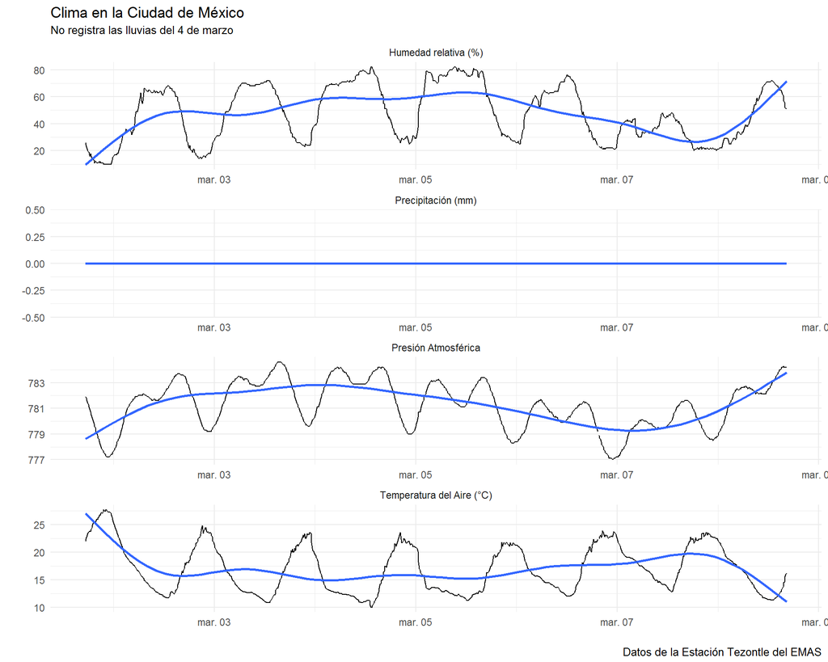

```r
#Serie de tiempo multipanel.

tezontle %>%
  mutate(fecha=ymd_hm(tezontle$`AAAA/MM/DD HH:MM HORAZ`)) %>%
  select(-`AAAA/MM/DD HH:MM HORAZ`) %>%
  gather(variable, dato, -fecha) %>%
  ggplot(aes(x=fecha, y=dato)) +
  geom_line() +
  geom_smooth(se=F) +
  facet_wrap(~variable, scales="free", ncol=1) +          #scales="free" para que cada panel tenga su propia escala.
  labs(caption="Datos de la Estación Tezontle del EMAS",
       y="",
       x="",
       title="Clima en la Ciudad de México",
       subtitle="No registra las lluvias del 4 de marzo") +
  theme_minimal()
```

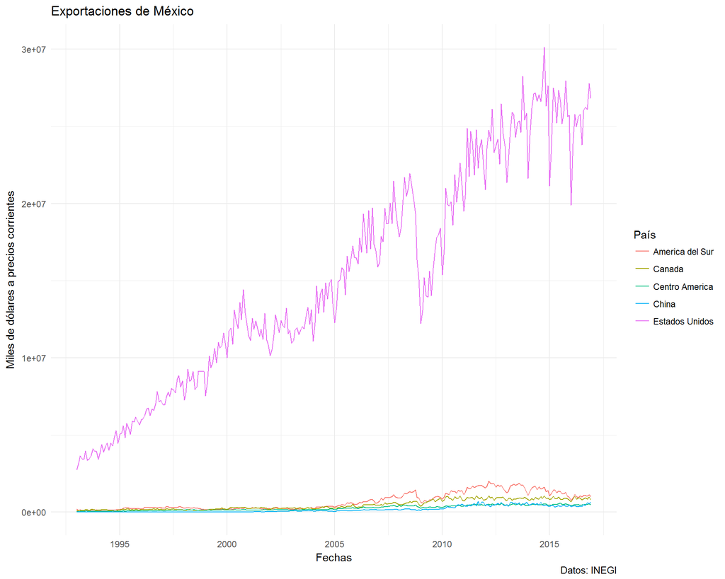

```r
#Serie de tiempo multicolor: todos en la misma escala.
series_exportaciones_pais(token) %>%
  gather(País, Monto, -Fechas) %>%                         #Paso los datos a formato largo.
  ggplot(aes(x=Fechas, y=Monto, group=País, color=País)) +
  geom_line() +
  labs(title="Exportaciones de México", y="Miles de dólares a precios corrientes", caption="Datos: INEGI") +
  theme_minimal()
```

# Descomposición de series de tiempo.

R incluye varios métodos para descomponer series de tiempo. El problema técnico es obtener un objeto de la clase `ts`, time series. Una vez que tenemos este objeto usamos `decompose()` para ajustar el modelo, al que podemos especificar como aditivo o multiplicativo. Con `stl()` podemos ajustar modelos más sofisticados.  
Los objetos de la clase `ts` son casi una reliquia y requieren algo de esfuerzo. Especificamos un objeto `ts` con la función `ts()` a la que pasamos un vector de valores –sin fecha–, la fecha de inicio y la periodicidad en meses. Funciona para series de tiempo con intervalos iguales.

## Objetos de la clase `ts`

```r
#Descomposición de series de tiempo.
#====================================

#Crear un objeto de la clase ts: serie de tiempo.

exportaciones_eeuu_ts <-
  ts(exportaciones$`Estados Unidos`,          #selecciono la columna de EEUU.
                            frequency = 12,   #La series es mensual, 12 puntos de datos.
                            start=c(1993, 1), #Inicio de la serie como vector c(año, mes)
                            end=c(2016, 12))  #Fin de la serie

class(exportaciones_eeuu_ts)                  #Pertenece a la clase ts
```

```
## [1] "ts"
```

```r
#Aplicar una descomposición aditiva.

str(decompose(exportaciones_eeuu_ts))         #Descomposición de la serie, por defecto aditiva.
```

```
## List of 6
##  $ x       : Time-Series [1:288] from 1993 to 2017: 2754262 3180064 3639819 3450809 3420962 ...
##  $ seasonal: Time-Series [1:288] from 1993 to 2017: -1978558 -1025620 540079 77700 537500 ...
##  $ trend   : Time-Series [1:288] from 1993 to 2017: NA NA NA NA NA ...
##  $ random  : Time-Series [1:288] from 1993 to 2017: NA NA NA NA NA ...
##  $ figure  : num [1:12] -1978558 -1025620 540079 77700 537500 ...
##  $ type    : chr "additive"
##  - attr(*, "class")= chr "decomposed.ts"
```

## Gráficos de descomposición de series de tiempo.

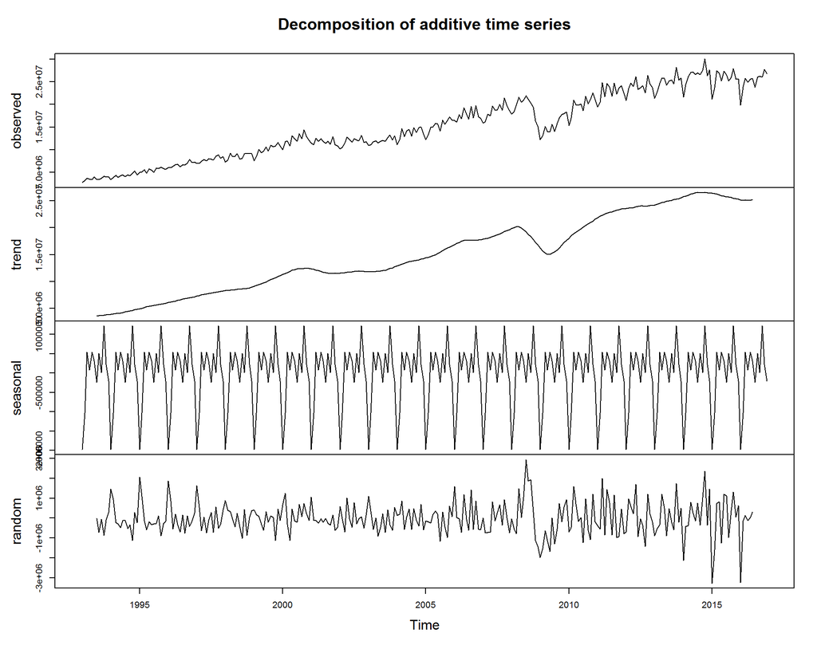

```r
#Gráfico estándar de la serie descompuesta. NO ggplot2.

plot(decompose(exportaciones_eeuu_ts))
```

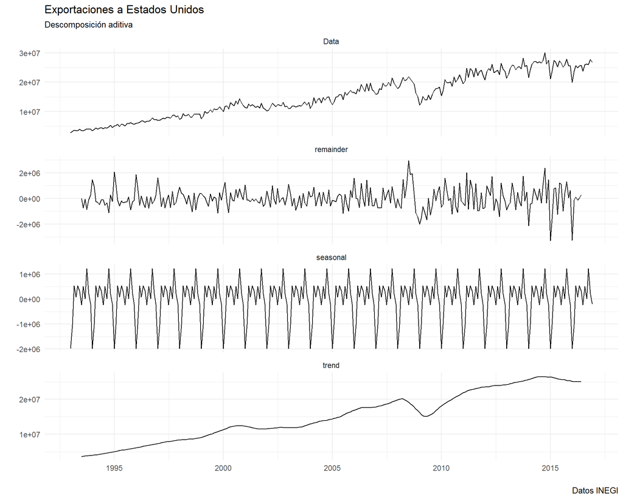

```r
#Gráfico de serie de tiempo descompuesta con ggplot2.

library(ggfortify)          #Requerida para pasar un objeto decomposed.ts a data.frame. Importa método autoplot.
library(hrbrthemes)         #Importa theme_ipsum() y scale_y_comma()

#Básico: nombres en inglés.
autoplot(decompose(exportaciones_eeuu_ts)) +
  labs(title="Exportaciones a Estados Unidos",
       subtitle="Descomposición aditiva",
       caption="Datos INEGI") +
  theme_minimal()
```

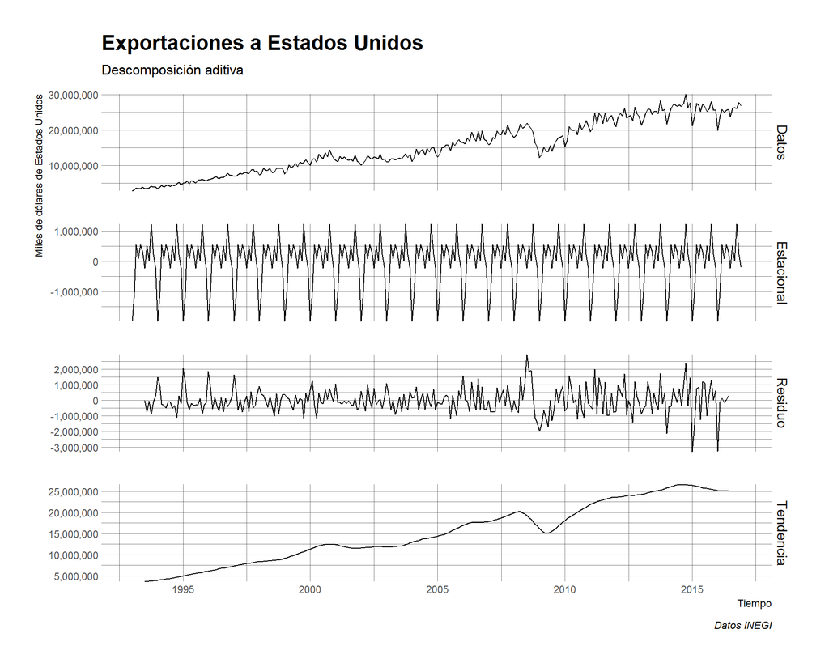

```r
#Modificado para nombres en español. Retocado para publicación.

fortify(decompose(exportaciones_eeuu_ts)) %>% #Convierte a la serie de tiempo descompuesta a data.frame
  rename("Datos"=Data,                        #Aquí cambio los nombres de columna.
         "Estacional"=seasonal,
         "Tendencia"=trend,
         "Residuo"=remainder) %>%
  gather(variable, valor, -Index) %>%        #Paso a formato largo con gather(), mantengo Index.
  ggplot(aes(x=Index, y=valor)) +            #Mapeo x y y
  geom_line() +                              #Elemento geométrico
  facet_grid(variable~., scales="free") +    #especifico los paneles. facet_grid etiquetado horizontal
  labs(title="Exportaciones a Estados Unidos",
       subtitle="Descomposición aditiva",
       caption="Datos INEGI",
       x="Tiempo",
       y="Miles de dólares de Estados Unidos") +
  theme_ipsum() +
  scale_y_comma()
```

[^1]: mpaladino@mora.edu.mx
[^2]: Un ejemplo más claro: la serie de tiempo de las visitas al médico de una persona. No suceden en un intervalo regular.